# Smoking

# 1 Description of DataSchema variable

The description of harmonised variable is the following:

- Short name: `smoking`
- Variable label: `Composite variable. Any type of tobacco smoking`
- Variable description: `Composite variable. Any type of tobacco smoking`
- Domain: `Lifestyle and health behaviours`
- Value type: `categorical`
- Category coding:

| **Code** | **Category Label** |
| --- | --- |
| 0 | never smoked |
| 1 | ex-smoker |
| 2 | current smoker |

- Category missings:

| **Code** | **Category Label** |
| --- | --- |
| 991 | CAPI/interviewer error |
| 992 | Impute |
| 993 | Disable to measure |
| 994 | Not attempt/not done |
| 995 | Does not answer |
| 996 | Not applicable |
| 997 | Refuse |
| 998 | Do not know |
| 999 | Missing |

# 2 Data process

## 2.1 England

### 2.1.1 Wave 1

#### 2.1.1.1 Study-specific variable description

| **Name** | `smokerstat` |
| --- | --- |
| **Label** | `smoker status (past or present)` |
| **Table name** | `wave_1_ifs_derived_variables` |
| **Categories:** | `0 = never smoked` `1 = ex smoker - occasional` `2 = ex smoker - regular` `3 = ex smoker - Don't know frequency` `4 = current smoker` |
| **Missings:** | `-2 = not asked` `-8 = don't know` `-9 = refused` |
| **Description** |  |

smokerstat

| Sample size | Missing values |
| --- | --- |
| 12099 | 191 |

Category

|  | 0 | 1 | 2 | 3 | 4 |
| --- | --- | --- | --- | --- | --- |
| Frequency | 4286.00 | 674.00 | 4342.00 | 445.00 | 2161.00 |
| Percentage | 35.42 | 5.57 | 35.89 | 3.68 | 17.86 |

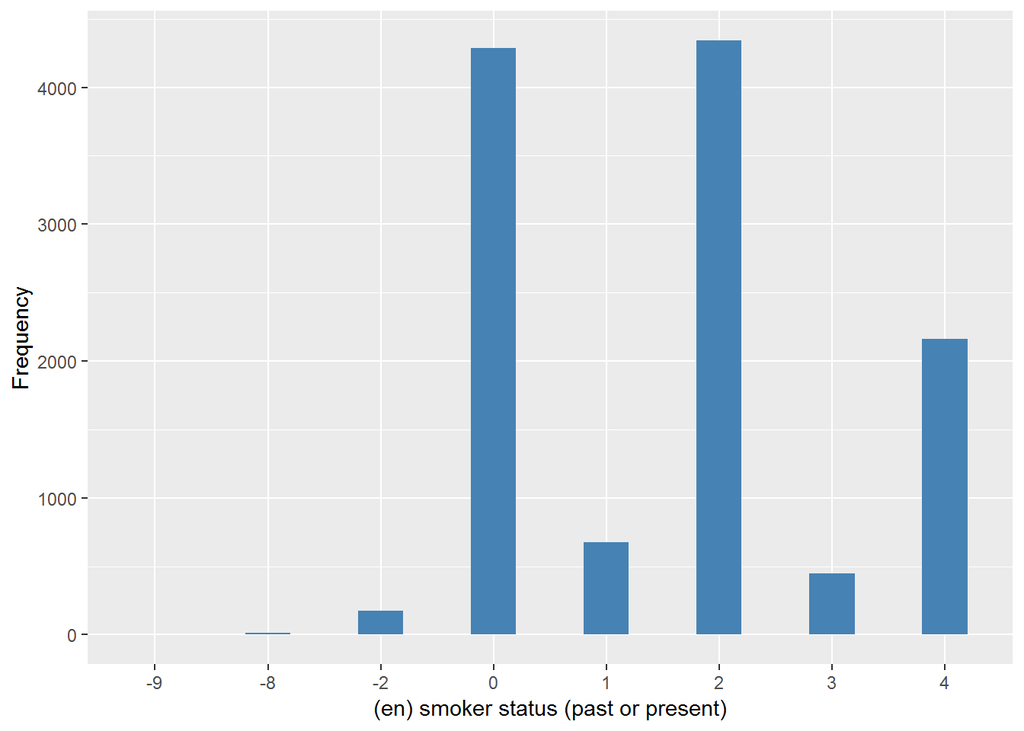

#### 2.1.1.2 Harmonisation algorithm

To compute `smoking` from the study-specific variable it has to be recoded as follows:

- `2,3 into 1`
- `4 into 2`
- `-2 into 994`
- `-8 into 998`
- `-9 into 997`

**R script:**

```r
ELSA_ds_w1 <- tibble(id = ELSA_w1$id)
ELSA_ds_w1$smoking <- car::recode(ELSA_w1$smokerstat, "2 = 1;3 = 1;4 = 2;-2 = 994;-8 = 998;-9 = 997 ")
```

#### 2.1.1.3 Statistical description of the new harmonised variable

Composite variable. Any type of tobacco smoking

| Sample size | Missing values |
| --- | --- |
| 12099 | 191 |

Category

|  | 0 | 1 | 2 |
| --- | --- | --- | --- |
| Frequency | 4286.00 | 5461.00 | 2161.00 |
| Percentage | 35.42 | 45.14 | 17.86 |

Type of missing

|  | 991 | 992 | 993 | 994 | 995 | 996 | 997 | 998 | 999 | NA |
| --- | --- | --- | --- | --- | --- | --- | --- | --- | --- | --- |
| Frequency | 0 | 0 | 0 | 175.00 | 0 | 0 | 5.00 | 11.00 | 0 | 0 |
| Percentage | 0 | 0 | 0 | 1.45 | 0 | 0 | 0.04 | 0.09 | 0 | 0 |

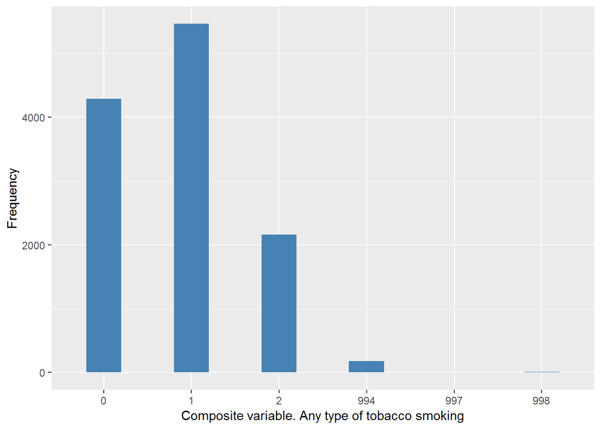

#### 2.1.1.4 Validation

|  | 0->0 | 1,2,3->1 | 4->2 | -2->994 | -9->997 | -8->998 |
| --- | --- | --- | --- | --- | --- | --- |
| BeforeH | 4286 | 5461 | 2161 | 175 | 5 | 11 |
| AfterH | 4286 | 5461 | 2161 | 175 | 5 | 11 |

### 2.1.2 Wave 2

#### 2.1.2.1 Study-specific variable description

| **Name** | `smokerstat` |
| --- | --- |
| **Label** | `smoker status (past or present)` |
| **Table name** | `wave_2_ifs_derived_variables` |
| **Categories:** | `0 = never smoked` `1 = ex smoker - occasional` `2 = ex smoker - regular` `3 = ex smoker - Don't know frequency` `4 = current smoker` |
| **Missings:** | `-2 = not asked` `-8 = don't know` `-9 = refused` |
| **Description** |  |

smokerstat

| Sample size | Missing values |
| --- | --- |
| 9432 | 7 |

Category

|  | 0 | 1 | 2 | 3 | 4 |
| --- | --- | --- | --- | --- | --- |
| Frequency | 3470.00 | 542.00 | 3582.00 | 356.00 | 1475.00 |
| Percentage | 36.79 | 5.75 | 37.98 | 3.77 | 15.64 |

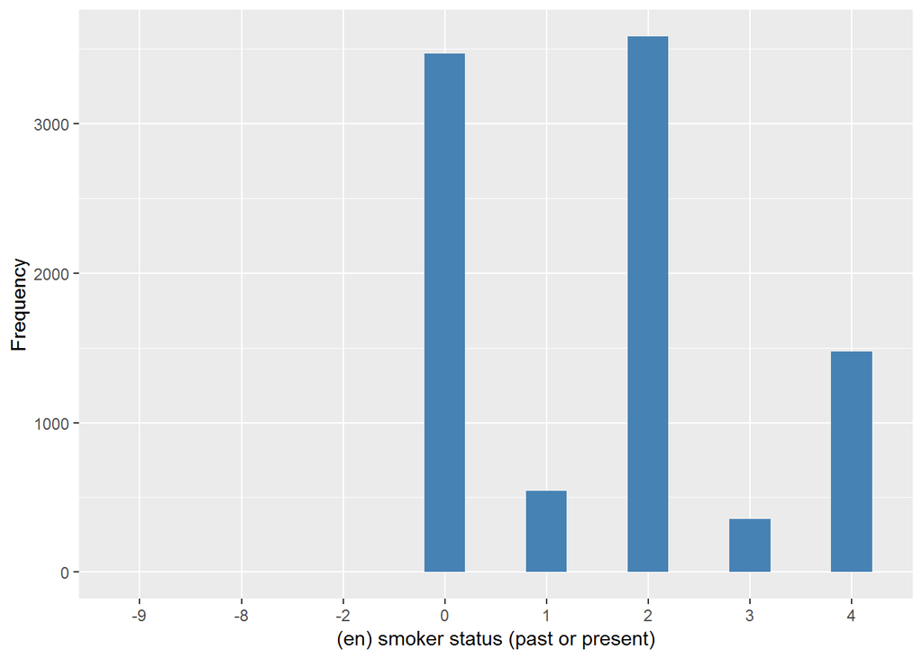

#### 2.1.2.2 Harmonisation algorithm

To compute `smoking` from the study-specific variable it has to be recoded as follows:

- `2,3 into 1`
- `4 into 2`
- `-2 into 994`
- `-8 into 998`
- `-9 into 997`

**R script:**

```r
ELSA_ds_w2 <- tibble(id = ELSA_w2$id)
ELSA_ds_w2$smoking <- car::recode(ELSA_w2$smokerstat, "2 = 1;3 = 1;4 = 2;-2 = 994;-8 = 998;-9 = 997 ")
```

#### 2.1.2.3 Statistical description of the new harmonised variable

Composite variable. Any type of tobacco smoking

| Sample size | Missing values |
| --- | --- |
| 9432 | 7 |

Category

|  | 0 | 1 | 2 |
| --- | --- | --- | --- |
| Frequency | 3470.00 | 4480.0 | 1475.00 |
| Percentage | 36.79 | 47.5 | 15.64 |

Type of missing

|  | 991 | 992 | 993 | 994 | 995 | 996 | 997 | 998 | 999 | NA |
| --- | --- | --- | --- | --- | --- | --- | --- | --- | --- | --- |
| Frequency | 0 | 0 | 0 | 2.00 | 0 | 0 | 1.00 | 4.00 | 0 | 0 |
| Percentage | 0 | 0 | 0 | 0.02 | 0 | 0 | 0.01 | 0.04 | 0 | 0 |

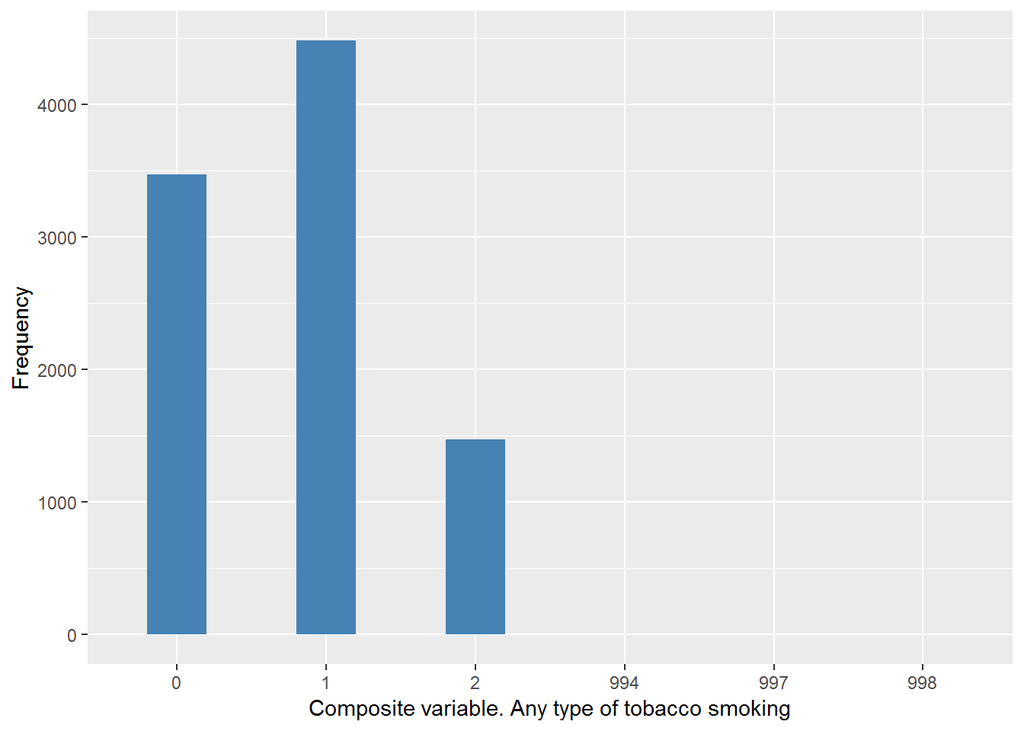

#### 2.1.2.4 Validation

|  | 0->0 | 1,2,3->1 | 4->2 | -2->994 | -9->997 | -8->998 |
| --- | --- | --- | --- | --- | --- | --- |
| BeforeH | 3470 | 4480 | 1475 | 2 | 1 | 4 |
| AfterH | 3470 | 4480 | 1475 | 2 | 1 | 4 |

### 2.1.3 Wave 3

#### 2.1.3.1 Study-specific variable description

| **Name** | `smokerstat` |
| --- | --- |
| **Label** | `smoker status (past or present)` |
| **Table name** | `wave_3_ifs_derived_variables` |
| **Categories:** | `0 = never smoked` `1 = ex smoker - occasional` `2 = ex smoker - regular` `3 = ex smoker - Don't know frequency` `4 = current smoker` |
| **Missings:** | `-2 = not asked` `-8 = don't know` `-9 = refused` |
| **Description** |  |

smokerstat

| Sample size | Missing values |
| --- | --- |
| 9771 | 9 |

Category

|  | 0 | 1 | 2 | 3 | 4 |
| --- | --- | --- | --- | --- | --- |
| Frequency | 3768.00 | 558.00 | 3558.00 | 369.00 | 1509.00 |
| Percentage | 38.56 | 5.71 | 36.41 | 3.78 | 15.44 |

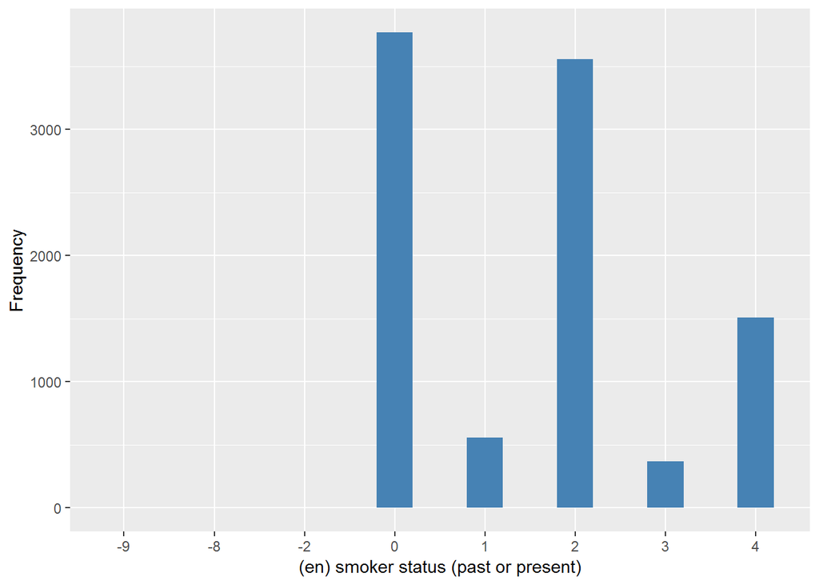

#### 2.1.3.2 Harmonisation algorithm

To compute `smoking` from the study-specific variable it has to be recoded as follows:

- `2,3 into 1`
- `4 into 2`
- `-2 into 994`
- `-8 into 998`
- `-9 into 997`

**R script:**

```r
ELSA_ds_w3 <- tibble(id = ELSA_w3$id)
ELSA_ds_w3$smoking <- car::recode(ELSA_w3$smokerstat, "2 = 1;3 = 1;4 = 2;-2 = 994;-8 = 998;-9 = 997 ")
```

#### 2.1.3.3 Statistical description of the new harmonised variable

Composite variable. Any type of tobacco smoking

| Sample size | Missing values |
| --- | --- |
| 9771 | 9 |

Category

|  | 0 | 1 | 2 |
| --- | --- | --- | --- |
| Frequency | 3768.00 | 4485.0 | 1509.00 |
| Percentage | 38.56 | 45.9 | 15.44 |

Type of missing

|  | 991 | 992 | 993 | 994 | 995 | 996 | 997 | 998 | 999 | NA |
| --- | --- | --- | --- | --- | --- | --- | --- | --- | --- | --- |
| Frequency | 0 | 0 | 0 | 4.00 | 0 | 0 | 2.00 | 3.00 | 0 | 0 |
| Percentage | 0 | 0 | 0 | 0.04 | 0 | 0 | 0.02 | 0.03 | 0 | 0 |

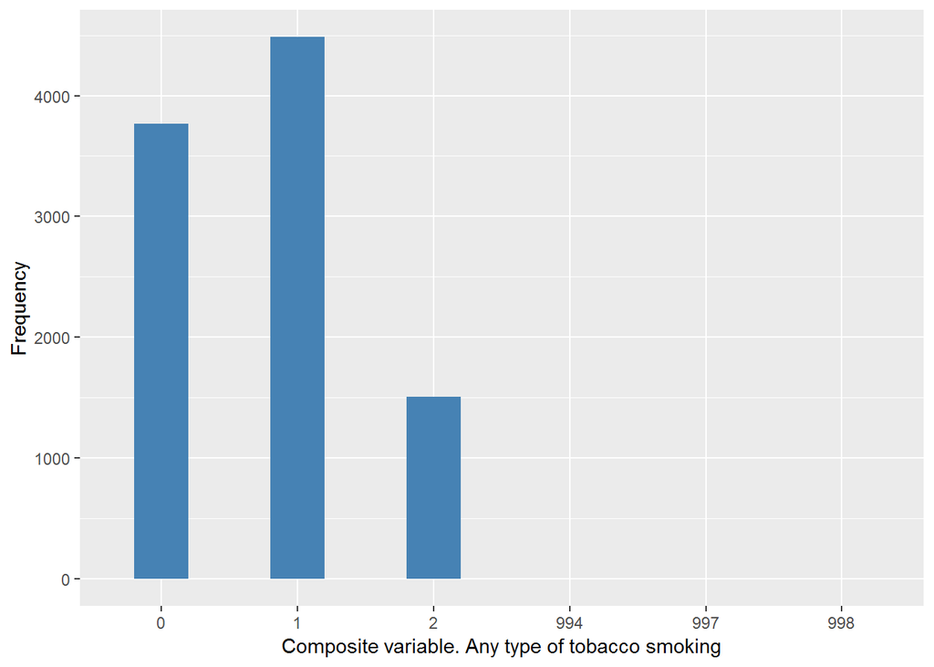

#### 2.1.3.4 Validation

|  | 0->0 | 1,2,3->1 | 4->2 | -2->994 | -9->997 | -8->998 |
| --- | --- | --- | --- | --- | --- | --- |
| BeforeH | 3768 | 4485 | 1509 | 4 | 2 | 3 |
| AfterH | 3768 | 4485 | 1509 | 4 | 2 | 3 |

### 2.1.4 Wave 4

#### 2.1.4.1 Study-specific variable description

| **Name** | `smokerstat` |
| --- | --- |
| **Label** | `smoker status (past or present)` |
| **Table name** | `wave_4_ifs_derived_variables` |
| **Categories:** | `0 = never smoked` `1 = ex smoker - occasional` `2 = ex smoker - regular` `3 = ex smoker - Don't know frequency` `4 = current smoker` |
| **Missings:** | `-2 = not asked` `-8 = don't know` `-9 = refused` |
| **Description** |  |

smokerstat

| Sample size | Missing values |
| --- | --- |
| 11050 | 226 |

Category

|  | 0 | 1 | 2 | 3 | 4 |
| --- | --- | --- | --- | --- | --- |
| Frequency | 4316.00 | 608.0 | 3944.00 | 411.00 | 1545.00 |
| Percentage | 39.06 | 5.5 | 35.69 | 3.72 | 13.98 |

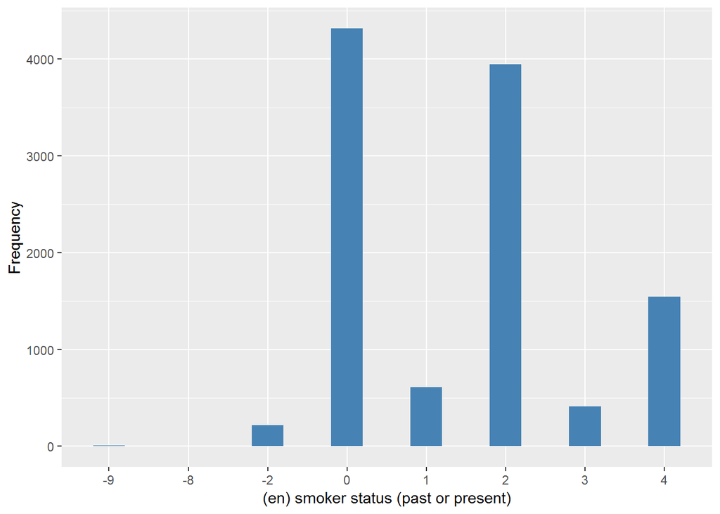

#### 2.1.4.2 Harmonisation algorithm

To compute `smoking` from the study-specific variable it has to be recoded as follows:

- `2,3 into 1`
- `4 into 2`
- `-2 into 994`
- `-8 into 998`
- `-9 into 997`

**R script:**

```r
ELSA_ds_w4 <- tibble(id = ELSA_w4$id)
ELSA_ds_w4$smoking <- car::recode(ELSA_w4$smokerstat, "2 = 1;3 = 1;4 = 2;-2 = 994;-8 = 998;-9 = 997 ")
```

#### 2.1.4.3 Statistical description of the new harmonised variable

Composite variable. Any type of tobacco smoking

| Sample size | Missing values |
| --- | --- |
| 11050 | 226 |

Category

|  | 0 | 1 | 2 |
| --- | --- | --- | --- |
| Frequency | 4316.00 | 4963.00 | 1545.00 |
| Percentage | 39.06 | 44.91 | 13.98 |

Type of missing

|  | 991 | 992 | 993 | 994 | 995 | 996 | 997 | 998 | 999 | NA |
| --- | --- | --- | --- | --- | --- | --- | --- | --- | --- | --- |
| Frequency | 0 | 0 | 0 | 217.00 | 0 | 0 | 6.00 | 3.00 | 0 | 0 |
| Percentage | 0 | 0 | 0 | 1.96 | 0 | 0 | 0.05 | 0.03 | 0 | 0 |

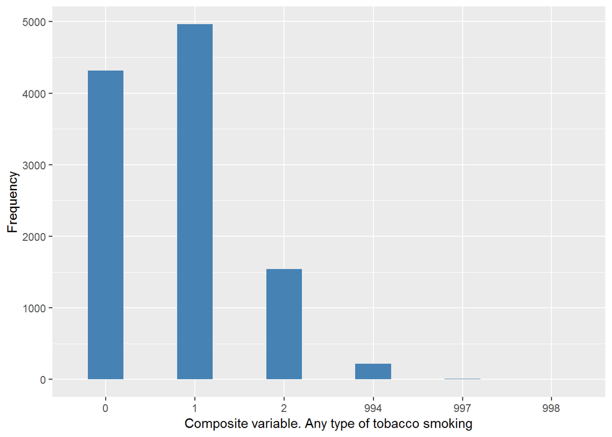

#### 2.1.4.4 Validation

|  | 0->0 | 1,2,3->1 | 4->2 | -2->994 | -9->997 | -8->998 |
| --- | --- | --- | --- | --- | --- | --- |
| BeforeH | 4316 | 4963 | 1545 | 217 | 6 | 3 |
| AfterH | 4316 | 4963 | 1545 | 217 | 6 | 3 |

### 2.1.5 Wave 5

#### 2.1.5.1 Study-specific variable description

| **Name** | `smokerstat` |
| --- | --- |
| **Label** | `smoker status (past or present)` |
| **Table name** | `wave_5_ifs_derived_variables` |
| **Categories:** | `0 = never smoked` `1 = ex smoker - occasional` `2 = ex smoker - regular` `3 = ex smoker - Don't know frequency` `4 = current smoker` |
| **Missings:** | `-2 = not asked` `-8 = don't know` `-9 = refused` |
| **Description** |  |

smokerstat

| Sample size | Missing values |
| --- | --- |
| 10274 | 307 |

Category

|  | 0 | 1 | 2 | 3 | 4 |
| --- | --- | --- | --- | --- | --- |
| Frequency | 3673.00 | 653.00 | 3821.00 | 508.00 | 1312.00 |
| Percentage | 35.75 | 6.36 | 37.19 | 4.94 | 12.77 |

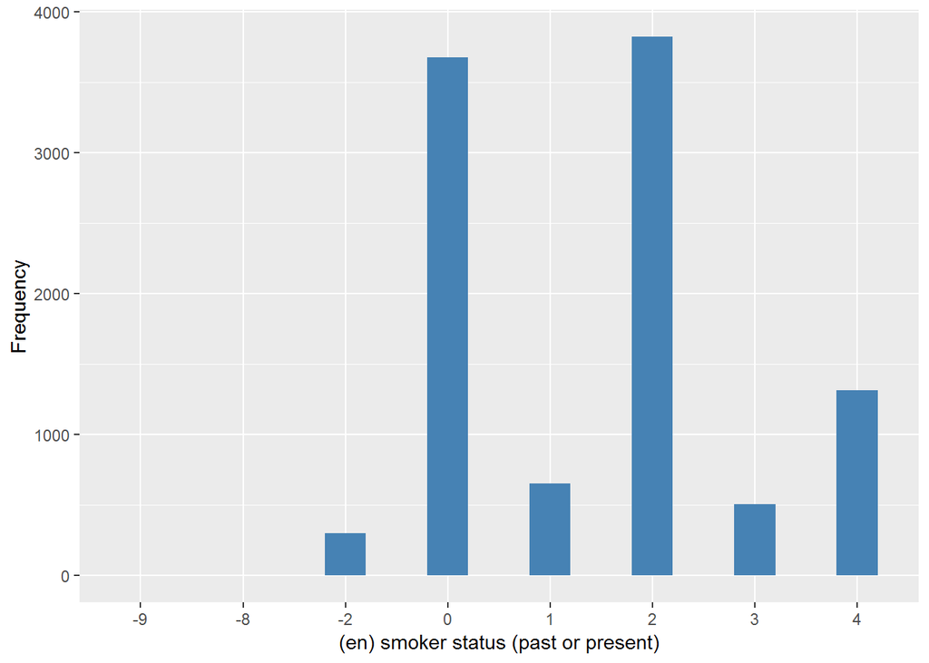

#### 2.1.5.2 Harmonisation algorithm

To compute `smoking` from the study-specific variable it has to be recoded as follows:

- `2,3 into 1`
- `4 into 2`
- `-2 into 994`
- `-8 into 998`
- `-9 into 997`

**R script:**

```r
ELSA_ds_w5 <- tibble(id = ELSA_w5$id)
ELSA_ds_w5$smoking <- car::recode(ELSA_w5$smokerstat, "2 = 1;3 = 1;4 = 2;-2 = 994;-8 = 998;-9 = 997 ")
```

#### 2.1.5.3 Statistical description of the new harmonised variable

Composite variable. Any type of tobacco smoking

| Sample size | Missing values |
| --- | --- |
| 10274 | 307 |

Category

|  | 0 | 1 | 2 |
| --- | --- | --- | --- |
| Frequency | 3673.00 | 4982.00 | 1312.00 |
| Percentage | 35.75 | 48.49 | 12.77 |

Type of missing

|  | 991 | 992 | 993 | 994 | 995 | 996 | 997 | 998 | 999 | NA |
| --- | --- | --- | --- | --- | --- | --- | --- | --- | --- | --- |
| Frequency | 0 | 0 | 0 | 302.00 | 0 | 0 | 3.00 | 2.00 | 0 | 0 |
| Percentage | 0 | 0 | 0 | 2.94 | 0 | 0 | 0.03 | 0.02 | 0 | 0 |

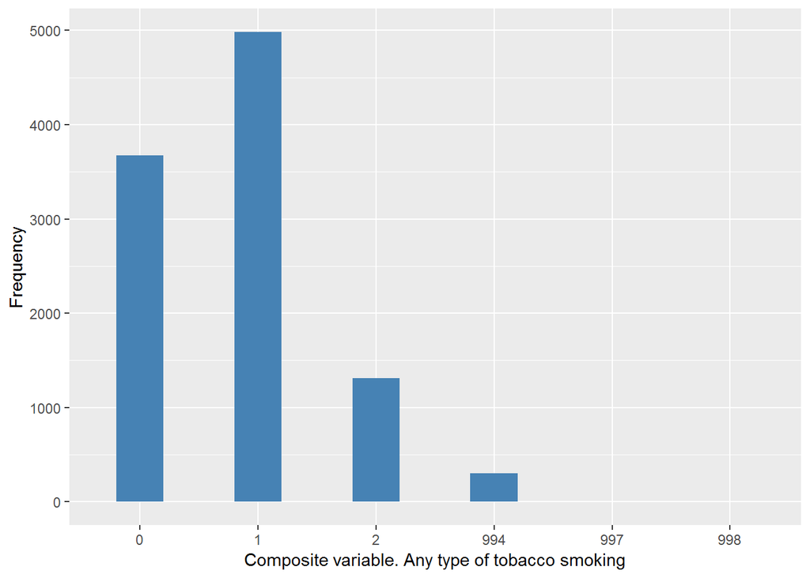

#### 2.1.5.4 Validation

|  | 0->0 | 1,2,3->1 | 4->2 | -2->994 | -9->997 | -8->998 |
| --- | --- | --- | --- | --- | --- | --- |
| BeforeH | 3673 | 4982 | 1312 | 302 | 3 | 2 |
| AfterH | 3673 | 4982 | 1312 | 302 | 3 | 2 |

### 2.1.6 Wave 6

#### 2.1.6.1 Study-specific variable description

| **Name** | `smokerstat` |
| --- | --- |
| **Label** | `smoker status (past or present)` |
| **Table name** | `wave_6_ifs_derived_variables` |
| **Categories:** | `0 = never smoked` `1 = ex smoker - occasional` `2 = ex smoker - regular` `3 = ex smoker - Don't know frequency` `4 = current smoker` |
| **Missings:** | `-2 = not asked` `-8 = don't know` `-9 = refused` |
| **Description** |  |

smokerstat

| Sample size | Missing values |
| --- | --- |
| 10601 | 170 |

Category

|  | 0 | 1 | 2 | 3 | 4 |
| --- | --- | --- | --- | --- | --- |
| Frequency | 3949.00 | 643.00 | 3603.00 | 920.00 | 1316.00 |
| Percentage | 37.25 | 6.07 | 33.99 | 8.68 | 12.41 |

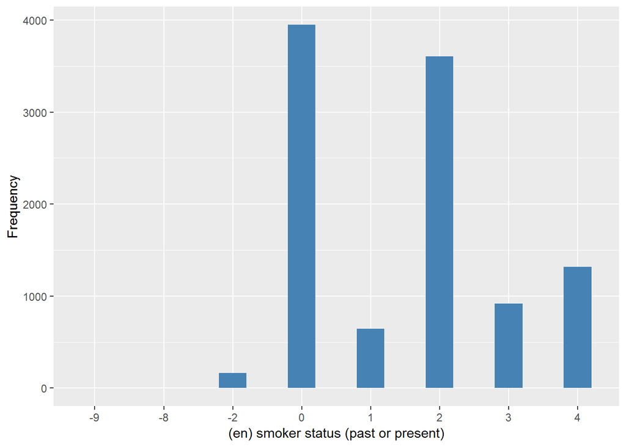

#### 2.1.6.2 Harmonisation algorithm

To compute `smoking` from the study-specific variable it has to be recoded as follows:

- `2,3 into 1`
- `4 into 2`
- `-2 into 994`
- `-8 into 998`
- `-9 into 997`

**R script:**

```r
ELSA_ds_w6 <- tibble(id = ELSA_w6$id)
ELSA_ds_w6$smoking <- car::recode(ELSA_w6$smokerstat, "2 = 1;3 = 1;4 = 2;-2 = 994;-8 = 998;-9 = 997 ")
```

#### 2.1.6.3 Statistical description of the new harmonised variable

Composite variable. Any type of tobacco smoking

| Sample size | Missing values |
| --- | --- |
| 10601 | 170 |

Category

|  | 0 | 1 | 2 |
| --- | --- | --- | --- |
| Frequency | 3949.00 | 5166.00 | 1316.00 |
| Percentage | 37.25 | 48.73 | 12.41 |

Type of missing

|  | 991 | 992 | 993 | 994 | 995 | 996 | 997 | 998 | 999 | NA |
| --- | --- | --- | --- | --- | --- | --- | --- | --- | --- | --- |
| Frequency | 0 | 0 | 0 | 166.00 | 0 | 0 | 3.00 | 1.00 | 0 | 0 |
| Percentage | 0 | 0 | 0 | 1.57 | 0 | 0 | 0.03 | 0.01 | 0 | 0 |

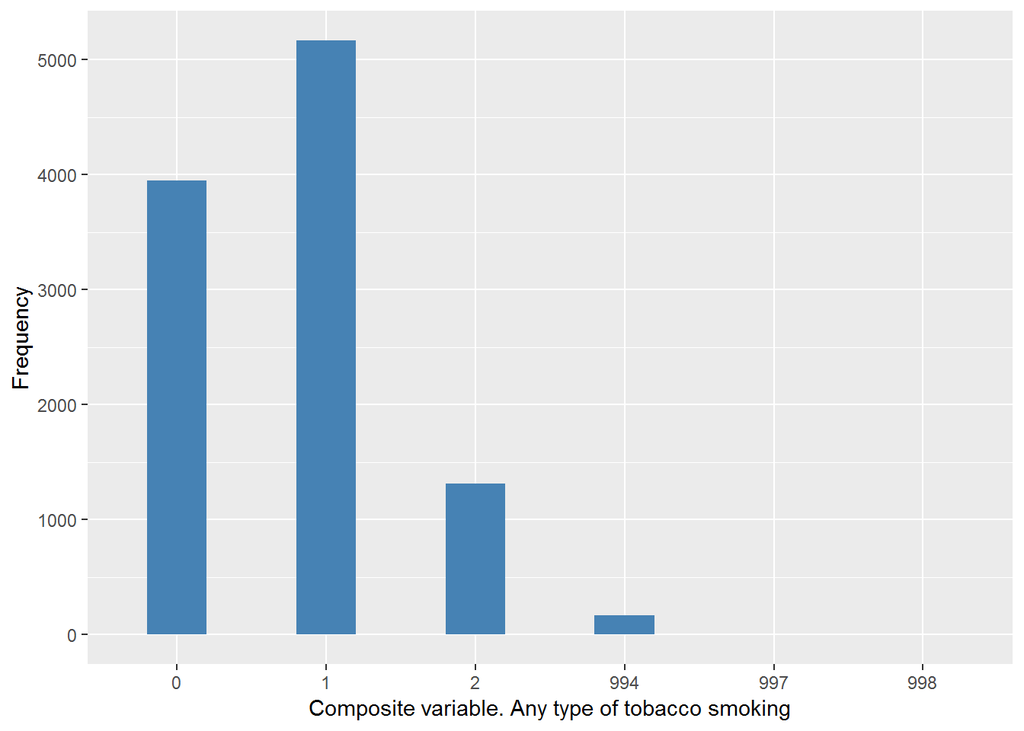

#### 2.1.6.4 Validation

|  | 0->0 | 1,2,3->1 | 4->2 | -2->994 | -9->997 | -8->998 |
| --- | --- | --- | --- | --- | --- | --- |
| BeforeH | 3949 | 5166 | 1316 | 166 | 3 | 1 |
| AfterH | 3949 | 5166 | 1316 | 166 | 3 | 1 |

### 2.1.7 Wave 7

#### 2.1.7.1 Study-specific variable description

| **Name** | `smokerstat` |
| --- | --- |
| **Label** | `smoker status (past or present)` |
| **Table name** | `wave7_dv` |
| **Categories:** | `0 = never smoked` `1 = ex smoker - occasional` `2 = ex smoker - regular` `3 = ex smoker - Don't know frequency` `4 = current smoker` |
| **Missings:** | `-2 = not asked` `-8 = don't know` `-9 = refused` |
| **Description** |  |

smokerstat

| Sample size | Missing values |
| --- | --- |
| 9666 | 152 |

Category

|  | 0 | 1 | 2 | 3 | 4 |
| --- | --- | --- | --- | --- | --- |
| Frequency | 3581.00 | 585.00 | 3260.00 | 994.00 | 1094.00 |
| Percentage | 37.05 | 6.05 | 33.73 | 10.28 | 11.32 |

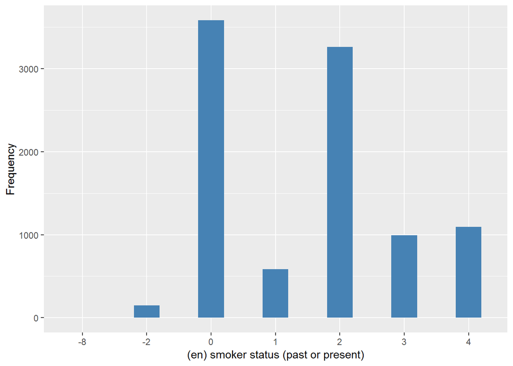

#### 2.1.7.2 Harmonisation algorithm

To compute `smoking` from the study-specific variable it has to be recoded as follows:

- `2,3 into 1`
- `4 into 2`
- `-2 into 994`
- `-8 into 998`
- `-9 into 997`

**R script:**

```r
ELSA_ds_w7 <- tibble(id = ELSA_w7$id)
ELSA_ds_w7$smoking <- car::recode(ELSA_w7$smokerstat, "2 = 1;3 = 1;4 = 2;-2 = 994;-8 = 998;-9 = 997 ")
```

#### 2.1.7.3 Statistical description of the new harmonised variable

Composite variable. Any type of tobacco smoking

| Sample size | Missing values |
| --- | --- |
| 9666 | 152 |

Category

|  | 0 | 1 | 2 |
| --- | --- | --- | --- |
| Frequency | 3581.00 | 4839.00 | 1094.00 |
| Percentage | 37.05 | 50.06 | 11.32 |

Type of missing

|  | 991 | 992 | 993 | 994 | 995 | 996 | 997 | 998 | 999 | NA |
| --- | --- | --- | --- | --- | --- | --- | --- | --- | --- | --- |
| Frequency | 0 | 0 | 0 | 151.00 | 0 | 0 | 0 | 1.00 | 0 | 0 |
| Percentage | 0 | 0 | 0 | 1.56 | 0 | 0 | 0 | 0.01 | 0 | 0 |

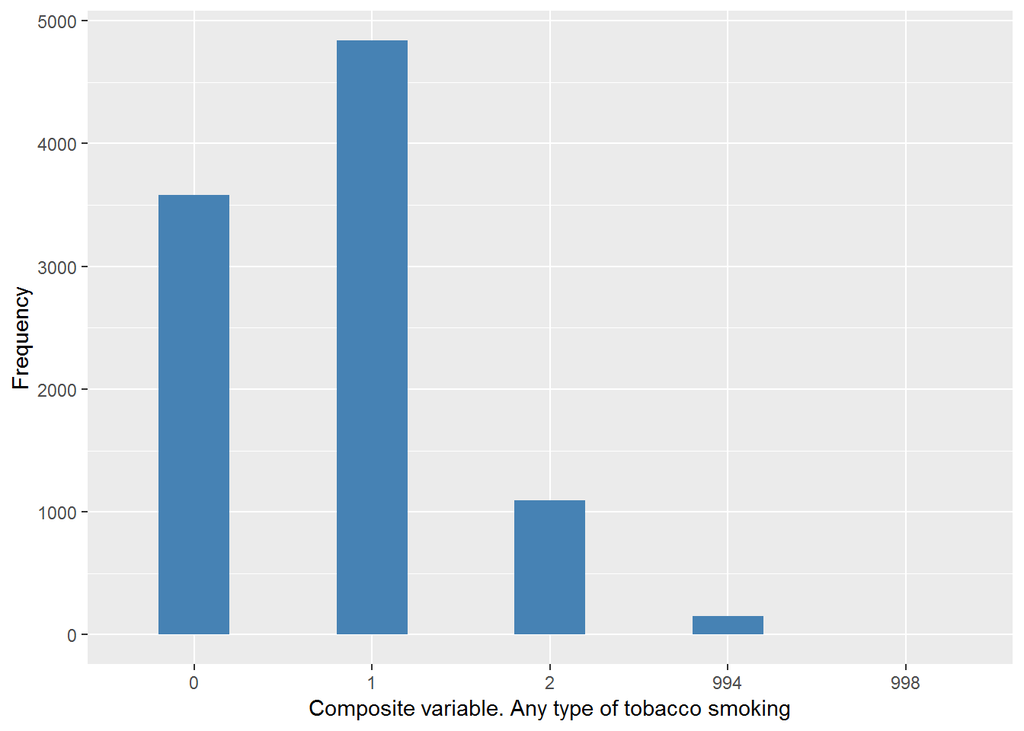

#### 2.1.7.4 Validation

|  | 0->0 | 1,2,3->1 | 4->2 | -2->994 | -8->998 |
| --- | --- | --- | --- | --- | --- |
| BeforeH | 3581 | 4839 | 1094 | 151 | 1 |
| AfterH | 3581 | 4839 | 1094 | 151 | 1 |

## 2.2 Summary of descriptive statistics of the harmonised variable accross populations and waves

Two tables are generated:

1. Percentages of categories in each harmonised variable.
2. Frequencies and percentages of individuals with different trajectories. To avoid too large table, Only trajectories with percentages larger than 0.3 are shown.

```r
t.hds <- frq(l.hds[[1]][2])[[1]][, c(1, 2)]
for (i in seq_along(l.hds)) {
    t.hds[2 + i] <- frq(l.hds[[i]][2])[[1]][, 4]
}
t.hds[14, ] <- c("n", "sample size", sapply(l.hds, function(wave) length(wave[[1]])))
names(t.hds) <- c("val", "label", names(l.hds))
kable(t.hds)
```

| val | label | w1 | w2 | w3 | w4 | w5 | w6 | w7 |
| --- | --- | --- | --- | --- | --- | --- | --- | --- |
| 0 | never | 35.42 | 36.79 | 38.56 | 39.06 | 35.75 | 37.25 | 37.05 |
| 1 | past | 45.14 | 47.5 | 45.9 | 44.91 | 48.49 | 48.73 | 50.06 |
| 2 | current | 17.86 | 15.64 | 15.44 | 13.98 | 12.77 | 12.41 | 11.32 |
| 991 | CAPI interviewer error | 0 | 0 | 0 | 0 | 0 | 0 | 0 |
| 992 | Impute | 0 | 0 | 0 | 0 | 0 | 0 | 0 |
| 993 | Disable to measure | 0 | 0 | 0 | 0 | 0 | 0 | 0 |
| 994 | Not attempt not done | 1.45 | 0.02 | 0.04 | 1.96 | 2.94 | 1.57 | 1.56 |
| 995 | Does not answer | 0 | 0 | 0 | 0 | 0 | 0 | 0 |
| 996 | Not applicable | 0 | 0 | 0 | 0 | 0 | 0 | 0 |
| 997 | Refuse | 0.04 | 0.01 | 0.02 | 0.05 | 0.03 | 0.03 | 0 |
| 998 | Do not know | 0.09 | 0.04 | 0.03 | 0.03 | 0.02 | 0.01 | 0.01 |
| 999 | Missing | 0 | 0 | 0 | 0 | 0 | 0 | 0 |
| NA | NA | 0 | 0 | 0 | 0 | 0 | 0 | 0 |
| n | sample size | 12099 | 9432 | 9771 | 11050 | 10274 | 10601 | 9666 |

```r
dbb <- get(paste0("ELSA_m_ds_", names(l.hds)[1]))[, c("id", "smoking")]
for (ind in 2:length(l.hds)) {
    dbb <- merge(dbb, get(paste0("ELSA_m_ds_", names(l.hds)[ind]))[, c("id",
        "smoking")], by = "id", suffixes = c("", paste0(".", names(l.hds)[ind])),
        all = T)
}
names(dbb) <- c("id", names(l.hds))

v.dbb <- dbb[, 2]
for (ind in 2:length(l.hds)) {
    v.dbb <- paste(v.dbb, dbb[, ind + 1], sep = "")
}
f.dbb <- frq(v.dbb)[[1]][, c(1, 2, 4)]
kable(f.dbb[f.dbb[, 3] >= 0.3, ])
```

|  | val | frq | raw.prc |
| --- | --- | --- | --- |
| 1 | 0000000 | 1485 | 8.03 |
| 3 | 000000NA | 210 | 1.14 |
| 8 | 00000NANA | 136 | 0.74 |
| 9 | 0000111 | 112 | 0.61 |
| 21 | 0000NANANA | 220 | 1.19 |
| 37 | 000NANANANA | 314 | 1.70 |
| 59 | 00NANANANANA | 394 | 2.13 |
| 98 | 0NANANANANANA | 664 | 3.59 |
| 105 | 1111111 | 1863 | 10.08 |
| 107 | 111111NA | 288 | 1.56 |
| 111 | 11111NANA | 207 | 1.12 |
| 122 | 1111NANANA | 285 | 1.54 |
| 131 | 111NA111 | 57 | 0.31 |
| 143 | 111NANANANA | 433 | 2.34 |
| 178 | 11NANANANANA | 590 | 3.19 |
| 246 | 1NANANANANANA | 924 | 5.00 |
| 247 | 2111111 | 82 | 0.44 |
| 368 | 2222222 | 254 | 1.37 |
| 369 | 222222NA | 63 | 0.34 |
| 377 | 2222NANANA | 73 | 0.39 |
| 394 | 222NANANANA | 116 | 0.63 |
| 422 | 22NANANANANA | 227 | 1.23 |
| 471 | 2NANANANANANA | 416 | 2.25 |
| 528 | NANA00000 | 338 | 1.83 |
| 544 | NANA00NANANA | 57 | 0.31 |
| 554 | NANA0NANANANA | 124 | 0.67 |
| 557 | NANA11111 | 282 | 1.53 |
| 586 | NANA1NANANANA | 103 | 0.56 |
| 610 | NANA22222 | 105 | 0.57 |
| 638 | NANA2NANANANA | 88 | 0.48 |
| 639 | NANANA0000 | 608 | 3.29 |
| 642 | NANANA000NA | 84 | 0.45 |
| 647 | NANANA00NANA | 61 | 0.33 |
| 657 | NANANA0NANANA | 129 | 0.70 |
| 661 | NANANA1111 | 666 | 3.60 |
| 663 | NANANA111NA | 101 | 0.55 |
| 668 | NANANA11NANA | 63 | 0.34 |
| 681 | NANANA1NANANA | 142 | 0.77 |
| 694 | NANANA2222 | 158 | 0.85 |
| 707 | NANANA2NANANA | 63 | 0.34 |
| 728 | NANANANANA00 | 400 | 2.16 |
| 730 | NANANANANA0NA | 97 | 0.52 |
| 731 | NANANANANA11 | 304 | 1.64 |
| 733 | NANANANANA1NA | 83 | 0.45 |
| 735 | NANANANANA22 | 147 | 0.80 |
| 736 | NANANANANA2NA | 56 | 0.30 |
| 737 | NANANANANANA0 | 233 | 1.26 |
| 738 | NANANANANANA1 | 145 | 0.78 |
| 739 | NANANANANANA2 | 103 | 0.56 |
| 740 | NANANANANANANA | 361 | 1.95 |

# 3 Quality estimation